# Confidence estimation

[Matt Jaquiery](https://github.com/mjaquiery) (matt.jaquiery@psy.ox.ac.uk)

December 2019

[Script run 2020-01-11 16:16:43]

# Introduction

Observations from [evolutionary models](https://github.com/oxacclab/EvoEgoBias) show that egocentric discounting is a successful strategy in environments where advisors cannot be clear on how advisors’ expressed confidence relates to their actual confidence. We reason that human participants may show a sensitivity to these contextual factors underlying advice-taking and respond to them in a rational manner. To test the effects of known versus unknown confidence representations, we manipulated whether participants believed advice to come from a consistent advisor or from one of a number of advisors on each trial in a judge-advisor system. Participants had two experimental blocks: in one the advice they received was always labelled as coming from a consistent individual, while in the other the advice was labelled as coming from a different advisor each time. All advice was drawn from the same distribution, which was centred on the correct answer (i.e. all of the advice was helpful on avereage).

After 10 trials in each block in which feedback on the correct answers was provided so participants could learn about the advisor/s, participants performed 5 trials without feedback.

We hypothesised that participants would place greater weight on the advice of the consistent advisor, presumably because they are able to learn about the calibration of the individual advisor while they cannot do likewise for the population of advisors.

# Method

The experimental code is available on [GitHub](https://github.com/oxacclab/ExploringSocialMetacognition), and the experiement can be performed by visiting [https://acclab.psy.ox.ac.uk/~mj221/ESM/ACBin/ce.html](https://acclab.psy.ox.ac.uk/~mj221/ESM/ACBin/ce.html?PROLIFIC_PID=WriteUp).

# Results

## Exclusions

```
[1] "NOTE: Testing (simulated) data!!!!"

        SingleFirst GroupFirst
  FALSE          18         12
```

Our final participant list consists of 30 participants who completed an average of 28.00 trials each, of which an average of 10.00 had no feedback.

## Task performance

First we offer a characterisation of the task, to provide the reader with a sense of how the participants performed.

### Decisions

Participants offered estimates of whether various events took place before or after a given year. The correct answers were always between 1900 and 2000. Participants answered by selecting a point on one of two confidence bars, with the choice of bar indicating the chosen answer.

#### Correctness

| decision | y | ymin | ymax |
| --- | --- | --- | --- |
| first | .786 | .709 | .863 |
| last | .821 | .772 | .871 |
| Overall | .804 | .743 | .865 |

| decision | y | ymin | ymax | feedback |
| --- | --- | --- | --- | --- |
| first | .780 | .699 | .861 | TRUE |
| last | .824 | .769 | .879 | TRUE |
| Overall | .802 | .736 | .867 | TRUE |

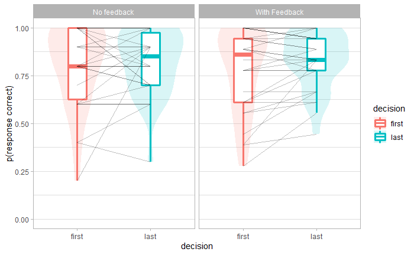

### Timing

We can look at the response time - the difference between the time the response is opened and the time the response is received.

| decision | y | ymin | ymax |
| --- | --- | --- | --- |
| first | 215 | 210 | 219 |
| last | 2582 | 2565 | 2600 |
| Overall | 1399 | 1387 | 1410 |

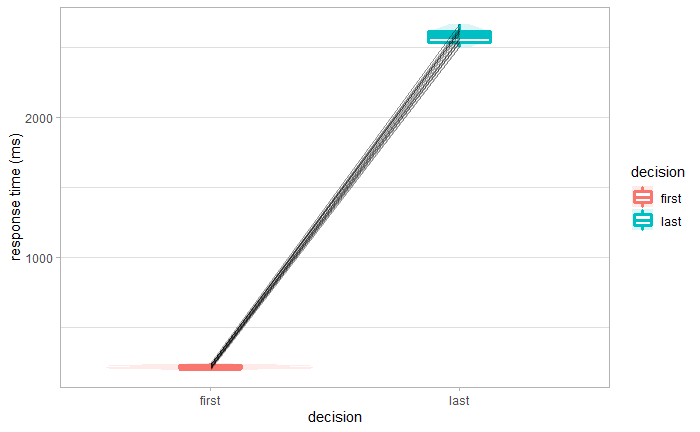

## Metacognitive performance

Participants indicated the confidence in their decisions simultaneously with the decisions themselves. We can thus explore how well a participant’s confidence signals their accuracy.

The first step in this process is to normalise confidence within that participant’s responses. This is done separately for first and last decisions.

### High/low split

We split confidence into simple high/low (above/below mean confidence) and explore the pCorrect for each side.

```
There were 18 warnings (use warnings() to see them)
```

| decision | y | ymin | ymax |
| --- | --- | --- | --- |
| first | .398 | .263 | .533 |
| last | .299 | .205 | .393 |
| Overall | .349 | .243 | .454 |

```
[1] "p(correct|high confidence) - p(correct|low confidence) for initial estimates"
Bayes factor analysis
--------------
[1] Alt., r=0.707 : 12143.31 ±0%

Against denominator:
  Null, mu = 0
---
Bayes factor type: BFoneSample, JZS

[1] "p(correct|high confidence) - p(correct|low confidence) for final decisions"
Bayes factor analysis
--------------
[1] Alt., r=0.707 : 41308.48 ±0%

Against denominator:
  Null, mu = 0
---
Bayes factor type: BFoneSample, JZS
```

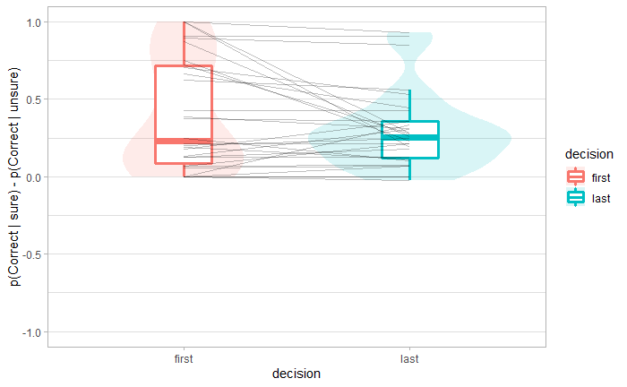